# Comprehensive Final Exam

Bayesian Statistics

Daniel Carpenter

May 2022

# Question 1

## 1. (a) General Posterior

*Adapted from JK’s book - page 132 Doing Bayesian Data Analysis:*

If $\theta \sim \operatorname{Beta}(\alpha, \beta)$ and $X \sim \operatorname{Bin}(n, \theta)$, prove that $\theta \mid X \sim \operatorname{Beta}(x+\alpha, n-x+\beta)$ through proof below:

$p(\theta \mid x) \propto p(\theta) p(x \mid \theta) = \frac{1}{B(\alpha, \beta)} \theta^{\alpha-1}(1-\theta)^{\beta-1}\left(\begin{array}{l}n \\ x\end{array}\right) \theta^{x}(1-\theta)^{n-x}$

Note Bayes’ rule  
$\underbrace{p(\theta \mid x)}_{Posterior} \propto \underbrace{p(\theta)}_{Prior} \underbrace{p(x \mid \theta)}_{Lik.} = \frac{p(x, n \mid \theta) p(\theta)}{p(x, n)} = p(\theta \mid x, n)$

Define Bernoulli and beta distributions  
$=\underbrace{\theta^{x}(1-\theta)^{(n-x)}}_{Bernoulli \ Lik.} \underbrace{\frac{\theta^{(\alpha-1)}(1-\theta)^{(\beta-1)}}{B(\alpha, \beta)}}_{Beta \ Prior} / p(x, n)$

Rearrange factors  
$=\frac{1}{B(\alpha, \beta) p(x, n)} \theta^{(\alpha-1)} (1-\theta)^{(\beta-1)} \theta^{x}(1-\theta)^{(n-x)}$

$=\frac{1}{B(\alpha, \beta)} \theta^{(\alpha-1)} (1-\theta)^{(\beta-1)} \left(\begin{array}{l}\frac{1}{p(x, n)}\end{array}\right)\theta^{x}(1-\theta)^{(n-x)}$

By definition of the binomial coefficient, which we arrive at the **solution**:  
$=\frac{1}{B(\alpha, \beta)} \theta^{(\alpha-1)} (1-\theta)^{(\beta-1)} \left(\begin{array}{l}n \\ x\end{array}\right) \theta^{x}(1-\theta)^{(n-x)}$

## 1. (b) If $\alpha$ = $\beta$ = 1 what prior distribution does this correspond to?

- Shape 1 and Shape two with values of 1 create a `uniform` distribution.

## 1. (c) Suppose she uses $\alpha$ = $\beta$ = 5 for the prior what is the posterior distribution?

- Mixing a beta-prior and bernoulli likelihood Creates a `Beta` prior and posterior`
- n=10, x=4, $\alpha$ = $\beta$ = 5

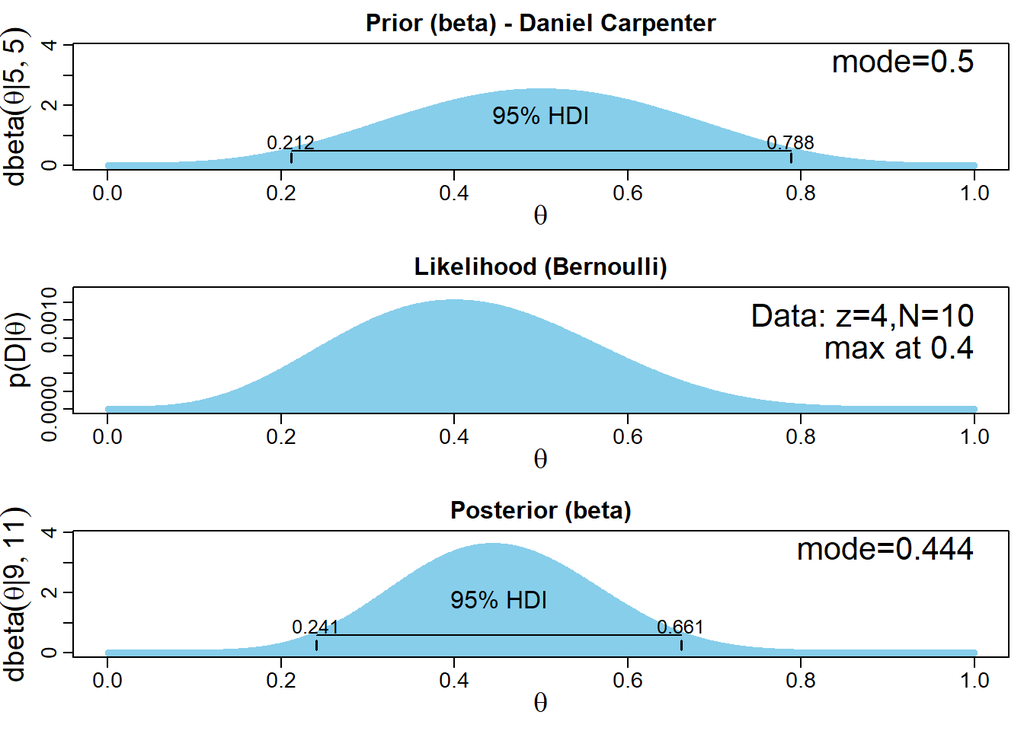

```r
# These need to be in your document directory to load
source("DBDA2E-utilities.R")  # Load definitions of graphics functions etc.
source("BernBeta.R")          # Load the definition of the BernBeta function

# Specify the prior:
t = 4              # Specify the prior MODE.
n = 10             # Specify the effective prior sample size.
a = 5              # Convert to beta shape parameter a.
b = 5              # Convert to beta shape parameter b.

Prior = c(a,b)     # Specify Prior as vector with the two shape parameters.

# Specify the data:
N = 10                        # The total number of flips.
x = 4                         # The number of heads.
Data = c(rep(0,N-x),rep(1,x)) # Convert N and z into vector of 0's and 1's.


# Plot the three graphs, and >> VIEW THE POSTERIOR <<:
posterior = BernBeta( priorBetaAB=Prior, Data=Data , plotType="Bars" ,
                      showCentTend="Mode" , showHDI=TRUE , showpD=FALSE )
```

## 1. (d) If a further experiment is made after the first using the same coin, this time with n = 20, x = 12, what prior should the researcher use in the absence of any other information than what is given in this problem?

- Since there is no additional information, use hyper parameters $\alpha$ = $\beta$ = 1 for this experiment.
- In question 1(f) we will mix the betas to get a more informed result

## 1. (e) Find the posterior after the second sequential experiment.

- Mixing a beta-prior and bernoulli likelihood Creates a `Beta posterior`
- n=20, x=12, $\alpha$ = $\beta$ = 1

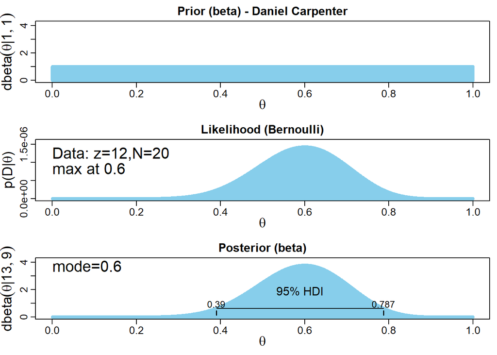

```r
# These need to be in your document directory to load
source("DBDA2E-utilities.R")  # Load definitions of graphics functions etc.
source("BernBeta.R")          # Load the definition of the BernBeta function

# Specify the prior:
t = 12              # Specify the prior MODE.
n = 20             # Specify the effective prior sample size.
a = 1              # Convert to beta shape parameter a.
b = 1              # Convert to beta shape parameter b.

Prior = c(a,b)     # Specify Prior as vector with the two shape parameters.

# Specify the data:
N = 20                        # The total number of flips.
x = 12                         # The number of heads.
Data = c(rep(0,N-x),rep(1,x)) # Convert N and z into vector of 0's and 1's.


# Plot the three graphs, and >> VIEW THE POSTERIOR <<:
posterior2 = BernBeta( priorBetaAB=Prior, Data=Data , plotType="Bars" ,
                       showCentTend="Mode" , showHDI=TRUE , showpD=FALSE )
```

## 1. (f) The researcher now wishes to plot the posterior (that which is formed from the two experiments). Fill in the gaps of the code so that the correct plot is created.

### Mixed beta Calculation:

$$w \times dbeta(x, a1, b1) + (1-w) \times dbeta(x, a2,b2)$$

### Mixed Beta function

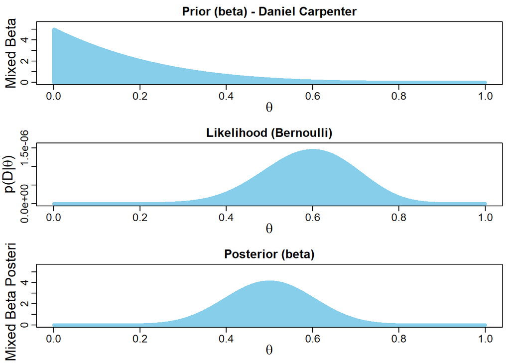

```r
Mymixbeta <- function(w=0.5, n=10, x, a1=1, a2=1, b1=1, b2=1) {
  # Specify the prior:
  t = x                          # Specify the prior MODE.

  # Specify the data:
  N = n                          # The total number of flips.
  z = x                          # The number of heads.
  Data = c(rep(0,N-z),rep(1,z))  # Convert N and z into vector of 0's and 1's.

  # Create summary values of Data:
  z = sum( Data ) # number of 1's in Data
  N = length( Data )

  Theta = seq(0.001,0.999,by=0.001)                                                 # points for plotting
  pTheta = w*dbeta(Theta,a1,b1) +(1-w)*dbeta(Theta,a2,b2)                           # prior for plotting
  pThetaGivenData = w*dbeta(Theta, a1+z, b1+N-z) + (1-w)*dbeta(Theta, a2+z, b2+N-z) # posterior for plotting
  pDataGivenTheta = Theta^z * (1-Theta)^(N-z)                                       # likelihood for plotting


  # Plot Layout
  layout( matrix( c( 1,2,3 ) ,nrow=3 ,ncol=1 ,byrow=FALSE ) ) # 3x1 panels
  par( mar=c(3,3,1,0) , mgp=c(2,0.7,0) , mai=c(0.5,0.5,0.3,0.1) ) # margins
  cexAxis = 1.33
  cexLab = 1.75

  # convert plotType to notation used by plot:
  plotType="h"
  dotsize = 5 # how big to make the plotted dots
  barsize = 5 # how wide to make the bar lines

  # y limits for prior and posterior:
  yLim = c(0,1.1*max(c(pTheta,pThetaGivenData)))


  # Plot the Prior
  plot( Theta , pTheta , type=plotType ,
        pch="." , cex=dotsize , lwd=barsize ,
        xlim=c(0,1) , ylim=yLim , cex.axis=cexAxis ,
        xlab=bquote(theta) , ylab='Mixed Beta' ,
        cex.lab=cexLab ,
        main="Prior (beta) - Daniel Carpenter" , cex.main=1.5 , col="skyblue")

  # Plot the likelihood
  plot( Theta , pDataGivenTheta , type=plotType ,
        pch="." , cex=dotsize , lwd=barsize ,
        xlim=c(0,1) , ylim=c(0,1.1*max(pDataGivenTheta)) , cex.axis=cexAxis ,
        xlab=bquote(theta) , ylab=bquote( "p(D|" * theta * ")" ) ,
        cex.lab=cexLab ,
        main="Likelihood (Bernoulli)" , cex.main=1.5 , col="skyblue" )

  # Plot the posterior.
  plot( Theta , pThetaGivenData , type=plotType ,
        pch="." , cex=dotsize , lwd=barsize ,
        xlim=c(0,1) , ylim=yLim , cex.axis=cexAxis ,
        xlab=bquote(theta) , ylab='Mixed Beta Posterior' ,
        cex.lab=cexLab ,
        main="Posterior (beta)" , cex.main=1.5 , col="skyblue" )
}

# Call the function and print the prior (mixed beta), likelihood and posterior)
Mymixbeta(w=0.5, n=20, x=12, a1=1, a2=1, b1=5, b2=5)
```

# Question 2 - Probability

## 2. a) P(X > 0.7|α = 2, $\beta$ = 3)

```r
pbeta(q = 0.7,
      shape1 = 2, shape2 = 3,
      lower.tail = FALSE) # >
```

```
## [1] 0.0837
```

## 2. b) P(X < 0.2|α = 1, $\beta$ = 1)

```r
pbeta(q = 0.2,
      shape1 = 1, shape2 = 1,
      lower.tail = TRUE) # <
```

```
## [1] 0.2
```

## 2. c) Find the value of X with lower tail probability 0.04. X ∼ Beta(5, 4)

```r
qbeta(p = 0.04,
      shape1 = 5, shape2 = 4,
      lower.tail = TRUE) # <
```

```
## [1] 0.2739266
```

## 2. d) Find the equal tail interval that contains 95% of the distribution, X ∼ Beta(4, 8)

```r
alphaCI = 0.05 / 2  # 2.5% upper/lower
a = 4 # shape 1
b = 8 # shape 2

# Upper tail 97.5%
upperTail = qbeta(p = alphaCI,
                  shape1=a, shape2=b,
                  lower.tail = FALSE) # <

# Lower tail 2.5%
lowerTail = qbeta(p = alphaCI,
                  shape1=a, shape2=b,
                  lower.tail = TRUE) # >
# Equal tail interval: 95% confidence between 2.5% and 97.5%
paste0('There is a ', (1 - alphaCI * 2) * 100, '% Probability that the value will fall between ',
      round(lowerTail, 3),' and ', round(upperTail, 3))
```

```
## [1] "There is a 95% Probability that the value will fall between 0.109 and 0.61"
```

## 2. e) Generate a random sample of X values of size 20 with X ∼ Beta(5, 7)

```r
randBetaDist <- rbeta(n = 20,
                      shape1 = 5,
                      shape2 = 7)

# Print the data
library(knitr)
kable(randBetaDist)
```

| x |
| --- |
| 0.3431556 |
| 0.3247137 |
| 0.5253816 |
| 0.3072908 |
| 0.1759318 |
| 0.2547435 |
| 0.4254333 |
| 0.3378725 |
| 0.2048030 |
| 0.3435794 |
| 0.3957062 |
| 0.5374887 |
| 0.6064266 |
| 0.3774096 |
| 0.3177849 |
| 0.1505935 |
| 0.2389538 |
| 0.4698357 |
| 0.4394095 |
| 0.3534691 |

# Question 3 - Interpret Posteriors

## 3. a) Give the 95% HDI for $\theta$ the probability of a success.

- There is a probability of 95% that the value will fall between 0.184 and 0.433

## 3. b) What is the posterior probability that $\theta$ < 0.5

- The posterior probability that $\theta$ < 0.5 is $99.7$%

## 3. c) If H0 : $\theta$ = 0.5 should we reject it (the NULL), yes/no?

- Yes, we should reject it because 0.5 falls outside the 95% and 90% HDI

## 3. d) The posterior probability that $\theta$ lies in (0.203, 0.413) is 0.90. True or False?

- It is `TRUE` that there is a probability of 90% that the value will fall between 0.203 and 0.413

## 3. e) What does ROPE stand for?

- ROPE stands for “Region Of Practical Equivalence”.
- In bayesian analysis, if the ROPE is entirely within the HDI for $\theta$ then we should reject the NULL for practical purposes.

# Question 4 - GLM

## 4. a) Link function?

- There is a logit link function used. Model:

$$logit(\theta) = log (\frac{\theta}{(1 − \theta)})$$

## 4. b) What numerical values will replace the y variable?

- The value of y is transformed onto a new scale, and that transformed value is modeled as a linear combination of predictors.
- Maps theta *from* `0-1` *to* the real value between $-\infty$ and $\infty$

## 4. c) High impact priors?

- No, they are `low` impact priors
- It means that the prior distribution will not impact the posterior significantly

## 4. d) Interpret Point/Interval Estimates

### 4. d, 1) $\beta_3$ Point Estimate

- The point estimate for $\beta_3$ is -0.75905 with a standard deviation of 0.199376.
- I.e. a male is more likely to die than a female.

### 4. d, 2) $\beta_1$ Interval Estimate

- There is a 95% probability that the values of $\beta_1$ will fall between 0.025778 and 0.6118

# Question 5 - Exponential Family

The exponential family can be defined as any density of the following form:
$$f(y \mid \theta, \phi)=\exp \left(\frac{y
\theta-b(\theta)}{a(\phi)}+c(y, \phi)\right)$$

## 5. a) Show $E(Y) = b^{\prime}(\theta)$

### Sum of distribution is 1

$$\int_y f(y)dy = 1 \\$$

### Differentiate above equation

$$\frac{d}{d\theta} \int_y f(y)dy = \frac{d}{d\theta} 1 = 0$$

### Take inside the integral

$$\int_y \frac{df}{d\theta} dy = 0$$

### Differentiate with $f$ being the exponential

$$\frac{df}{d\theta} =
\frac{y -b^{\prime}(\theta)}{a(\phi)} \
\exp \left(\frac{y \theta-b(\theta)}{a(\phi)}
+ c(y, \phi)\right)$$

### Replace with $f$ since it is the expontial

$$\frac{df}{d\theta} =
\frac{y -b^{\prime}(\theta)}{a(\phi)} \ f$$

### Plug $\int_y \frac{df}{d\theta} dy = 0$ into above $\frac{df}{d\theta}$

$$\int_y \begin{bmatrix} \frac{y -b^{\prime}(\theta)}{a(\phi)}
\end{bmatrix} \ f \ dy = 0$$

### Distribute $f$

$$\int_y \begin{bmatrix} \frac{yf -b^{\prime}(\theta)f}{a(\phi)}
\end{bmatrix} \ f \ dy = 0$$

### Multiply by $a(\phi)$ to get rid of it

$$\int_y yf \ dy
- \int_y b^{\prime}(\theta)f \ dy= 0$$

### Writing above in terms of E(Y)

$$E(Y) - b^{\prime}(\theta) \ \int_yf \ dy= 0$$

### *Solution*: Therefore, the expected value of Y $E(Y)$ is $b^{\prime}(\theta)$

$$E(Y) = b^{\prime}(\theta)$$

## 5. b) Show $V(Y) = b^{\prime \prime}(\theta) a(\phi)$

### From the prior proof above

$$\frac{df}{d\theta} =
\begin{bmatrix} \frac{y -b^{\prime}(\theta)}{a(\phi)} \end{bmatrix} \ f$$

### Get the second derivative of above

$$\frac{d^2f}{d\theta^2} =
\frac{-b^{\prime \prime}(\theta)}{a(\phi)} \ f
+ \frac{y -b^{\prime}(\theta)}{a(\phi)} \ f^{\prime}$$

### Replace above $f^{\prime}$ with $f$ from prior proof (two above points)

$$\frac{d^2f}{d\theta^2} =
\frac{-b^{\prime \prime}(\theta)}{a(\phi)} \ f
+ \begin{bmatrix} \frac{y -b^{\prime}(\theta)}{a(\phi)} \end{bmatrix}^2
\ f$$

### Note sum is 1 for all densities

$$\int_y dy = 1 \\$$

### Take 2nd dertivative using above notes to get 0

$$\int_y \frac{d^2f}{d\theta^2} \ dy = 0$$

### Plug $\frac{d^2f}{d\theta^2}$ into above equation

$$\int_y
\begin{pmatrix}
\frac{-b^{\prime \prime}(\theta)}{a(\phi)} \ f
+ \begin{bmatrix} \frac{y -b^{\prime}(\theta)}{a(\phi)} \end{bmatrix}^2
\ f
\end{pmatrix} \
dy = 0$$

### Simplify prior equation and isolate $\frac{-b^{\prime \prime}(\theta)}{a(\phi)}$

$$\frac{-b^{\prime \prime}(\theta)}{a(\phi)} \
\int_y f \ dy
+ \int_y \frac{(y -b^{\prime}(\theta))^2}{a(\phi)^2}
\ f \ dy = 0$$

### Plug expected value $E(Y)$ from prior proof knowledge that $E(Y)$ = $b^{\prime}(\theta)$

$$\frac{-b^{\prime \prime}(\theta)}{a(\phi)}
+ \frac{1}{a(\phi)^2} \
\int_y (y - E(Y))^2
\ f \ dy = 0$$

### Subsititute Variance $\sigma^2$ for $(y - E(Y))^2$

$$\frac{-b^{\prime \prime}(\theta)}{a(\phi)}
+ \frac{1}{a(\phi)^2} \
\sigma^2 = 0$$

### Simplify by Multiplying by $a(\phi)$

$$-b^{\prime \prime}(\theta) \ a(\phi) + \sigma^2 = 0$$

### *Solution*: Therefore, we get see that the variance $\sigma^2$ is $b^{\prime \prime}a(\phi)$

$$V(Y) = \sigma^2 = b^{\prime \prime}a(\phi)$$

## 5. c) Show that the `Binomial` distribution belongs to the `exponential` family

### Given the binomial definition, rearrange:

$$\begin{aligned}
p(Y = y) &=\left(\begin{array}{c}
n \\ y
\end{array}\right) p^{y}(1-p)^{n-y} \\
&=\left(\begin{array}{c}
n \\ y
\end{array}\right)(1-p)^{n}\left(\frac{p}{1-p}\right)^{y} \\
\end{aligned}$$

### Therefore we see it is apart of the exponential family

$$p(Y = y) =
\left(\begin{array}{l} n \\ y
\end{array}\right)(1-p)^{n} \exp \left(\log \left(\frac{p}{1-p}\right)
y\right)$$

## 5. d) Show $E(Y) = np$

### Using the definition of a Moment Generating Function

$$b(y ; n, p)=\frac{n !}{y !(n-y) !} p^{y} q^{n-y} \quad \text { with }
\quad q=1-p .$$

### MGF Given by:

$$\begin{aligned}
M(y, t) &=\sum_{y=0}^{n} e^{y t} \frac{n !}{y !(n-y) !} p^{y}
q^{n-y} \\
&=\sum_{y=0}^{n} \frac{n !}{y !(n-y) !}\left(p e^{t}\right)^{y}
q^{n-y} \\
&=\left(p e^{t}+q\right)^{n}
\end{aligned}$$

### Differentiate the MGF with respect to $t$ using the function-of-a-function rule:

$$\begin{aligned}
\frac{d M(y, t)}{d t} &=n\left(q+p e^{t}\right)^{n-1} p e^{t} \\
&=n p e^{t}\left(p e^{t}+q\right)^{n-1}
\end{aligned}$$

### *Solution*: Now use $t=0$ to get $E(Y)$, which is = $n p$

$$\begin{aligned}
E(Y) &=n p(p+q)^{n-1} \\
&=n p
\end{aligned}$$

## 5. e) Show $V(Y) = np(1−p)$

### Find the second moment using product rule:

$$\frac{d u v}{d y}=u \frac{d v}{d y}+v \frac{d u}{d y}$$
$$\begin{aligned}
\frac{d^{2} M(y, t)}{d t^{2}} &=n p e^{t}\left\{(n-1)\left(p
e^{t}+q\right)^{n-2} p e^{t}\right\}+\left(p
e^{t}+q\right)^{n-1}\left\{n p e^{t}\right\} \\
&=n p e^{t}\left(p e^{t}+q\right)^{n-2}\left\{(n-1) p e^{t}+\left(p
e^{t}+q\right)\right\} \\
&=n p e^{t}\left(p e^{t}+q\right)^{n-2}\left\{q+n p e^{t}\right\} .
\end{aligned}$$

### Use $t=0$ again:

$$\begin{aligned}
E\left(y^{2}\right) &=n p(p+q)^{n-2}(n p+q) \\
&=n p(n p+q)
\end{aligned}$$

### Derive $V(Y)=E(Y-\mu)^{2}$, in turn this means that $V(Y) = np(1 - p)$

> You could also write it as $V(Y) = n p q$ where $q=1-p$

$$\begin{aligned}
E(Y) &=E\left(y^{2}\right)-\{E(Y)\}^{2} \\
&=n p(n p+q)-n^{2} p^{2} \\
&=n p q \\
\end{aligned}$$

### *Solution*: Knowing that $q = 1 - p$, we know $V(Y) = n p (1 - p)$ from above $n p q$

## $$V(Y) = n p (1 - p)$$

# Question 6 - Derive Evidence

*Some of the derivation below may look similar to question 1 (a):*  
*Adapted from JK’s book - page 132 Doing Bayesian Data Analysis:*

If $\theta \sim \operatorname{Beta}(\alpha, \beta)$ and $X \sim \operatorname{Bin}(n, \theta)$, prove that $\theta \mid X \sim \operatorname{Beta}(x+\alpha, n-x+\beta)$ through proof below:

$p(\theta \mid x) \propto p(\theta) p(x \mid \theta) = \frac{1}{B(\alpha, \beta)} \theta^{\alpha-1}(1-\theta)^{\beta-1}\left(\begin{array}{l}n \\ x\end{array}\right) \theta^{x}(1-\theta)^{n-x}$

Note Bayes’ rule
$$\underbrace{p(\theta \mid x)}_{Posterior} \propto
\underbrace{p(\theta)}_{Prior} \underbrace{p(x \mid \theta)}_{Lik.}
\ / \underbrace{p(x)}_{Evidence}
= \frac{p(x, n \mid \theta) p(\theta)}{p(x, n)} / p(x) = p(\theta \mid
x, n) / p(x)$$

Define Bernoulli and beta distributions  
$=\underbrace{\theta^{x}(1-\theta)^{(n-x)}}_{Bernoulli \ Lik.} \underbrace{\frac{\theta^{(\alpha-1)}(1-\theta)^{(\beta-1)}}{B(\alpha, \beta)}}_{Beta \ Prior} / p(x, n) / p(x)$

Rearrange factors  
$=\frac{1}{B(\alpha, \beta) p(x, n)} \theta^{(\alpha-1)} (1-\theta)^{(\beta-1)} \theta^{x}(1-\theta)^{(n-x)} / p(x)$

$=\frac{1}{B(\alpha, \beta)} \theta^{(\alpha-1)} (1-\theta)^{(\beta-1)} \left(\begin{array}{l}\frac{1}{p(x, n)}\end{array}\right)\theta^{x}(1-\theta)^{(n-x)} / p(x)$

By definition of the binomial coefficient, which we arrive at the solution *in terms of `posterior`*:
$$\underbrace{p(\theta \mid x)}_{Posterior} =
\frac{\frac{1}{B(\alpha, \beta)} \theta^{(\alpha-1)}
(1-\theta)^{(\beta-1)} \left(\begin{array}{l}n \\ x\end{array}\right)
\theta^{x}(1-\theta)^{(n-x)}}
{\underbrace{p(x)}_{Evidence}}$$

*Final Solution*: By rearranging to be *in terms of the `evidence`*
$$\underbrace{p(x)}_{Evidence} = \frac{\frac{1}{B(\alpha, \beta)}
\theta^{(\alpha-1)} (1-\theta)^{(\beta-1)} \left(\begin{array}{l}n \\
x\end{array}\right) \theta^{x}(1-\theta)^{(n-x)}} {\underbrace{p(\theta
\mid x)}_{Posterior}}$$

# Question 7 - 2 State MCMC

## 7. a) Find the value of `A`

- Since the die landed on 6, and 6 is $\notin$ `E1` (current acceptance set), then
- Reject the proposal of 2 and stay at state 1
- Therefore, `A` = State `1`

## 7. b) Find the value of `B`

- Since we are at state `2` and the proposal state is state `1`, the value of alpha (or `B`) is `0.67`

## 7. c) Find the value of `C`

- Since the die landed on 6, and 6 is $\in$ `E2` (current acceptance set), then
- Accept the proposal and change to at state 1
- Therefore, `C` = State `1`

## 7. d) Formula for the acceptance probability

Note below is from page 33 of *Teaching MCMC* by Stewart & Stewart:

$$\alpha_{i, j}=\min \left\{1, \frac{h_{j}}{h_{i}}\right\}$$

where $\alpha_{i, j}$ is the probability of accepting state $j$ given that the sampler is at state $i$.

# Question 8 - SLR JAGS

## 8. a) SLR Doodle Bug

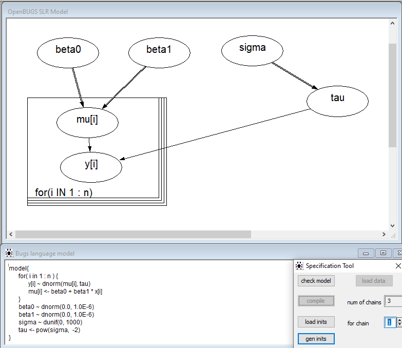

## 8. b) JAGS Code

> Jags code for the model using uniform’s on the sigma’s
- The data came as a data frame of x and y values with a total of n rows

```r
model{
    for( i in 1 : n ) {
        y[i] ~ dnorm(mu[i], tau)
        mu[i] <- beta0 + beta1 * x[i]
    }
    beta0 ~ dnorm(0.0, 1.0E-6)
    beta1 ~ dnorm(0.0, 1.0E-6)
    sigma ~ dunif(0, 1000)
    tau <- pow(sigma,  -2)
}
```

## 8. c) Logical Node?

- `tau` is considered a logical node,
- Because `tau` is logically related to `sigma`
- `tau` is a function of sigma.

## 8. d) Linear Predictors?

The linear predictor variables are: $\beta_0 +\beta_1 x$

# Question 9 - Change Point Regression

```r
dataList = list(x = c(-10, -9, -8, -7, -6, -5, -4, -3, -2, -1, 0, 1, 2,
3, 4, 5, 6, 7, 8, 9, 10), y = c(21.72, 20.41, 14.06, 14.6, 13.8,
10.4, 8.22, 6.79, 4.92, 0.45, 4.57, 1.95, 10.14, 13.28, 21.88,
18.88, 22.91, 23.53, 34.99, 35.07, 39.17), N = 21)
```

```r
df = data.frame(x = dataList$x, y=dataList$y)
head(df)
```

```
##     x     y
## 1 -10 21.72
## 2  -9 20.41
## 3  -8 14.06
## 4  -7 14.60
## 5  -6 13.80
## 6  -5 10.40
```

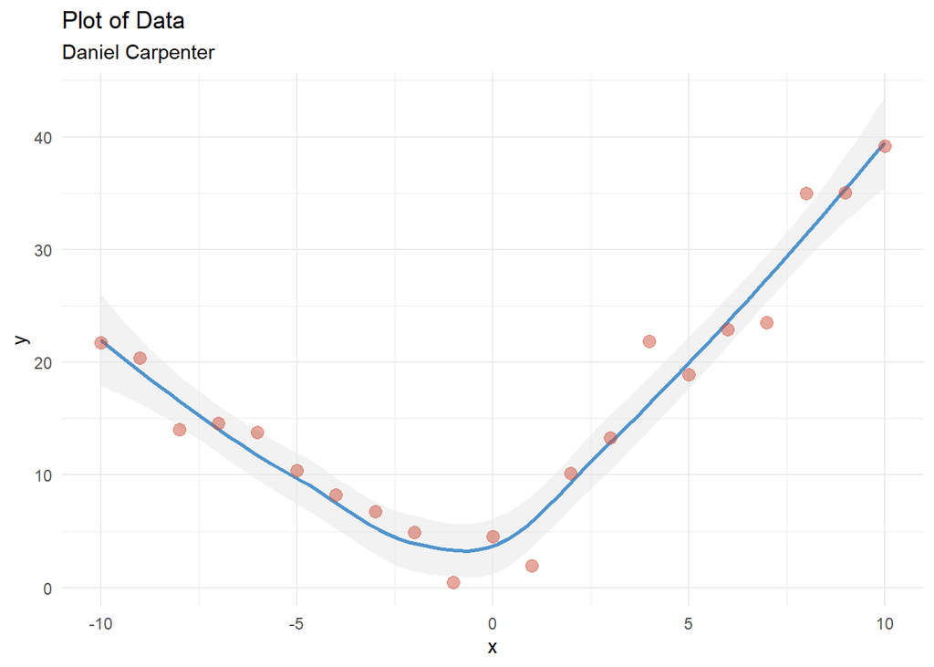

```r
library(ggplot2)
basePlot <- ggplot(df, aes(x=x, y=y)) +
              geom_smooth(method = 'loess', se = TRUE,
                          color = 'steelblue3', fill = 'grey90', alpha = 0.5) +
              geom_point(color ='tomato3', alpha = 0.5, size = 3) +
              theme_minimal() +
              labs(title = 'Plot of Data',
                   subtitle = 'Daniel Carpenter')
basePlot
```

## 9. b) JAGS Piecewise

### 9. b,i) Jags Code

```r
library(rjags)
#Define the model:
modelString = "
model {
  for (i in 1:N) {
    y[i]    ~ dnorm(mu[i], tau)
    mu[i]  <- beta0 + beta[1]*x[i] + beta[2]*(x[i] - theta)
            * step(x[i] - theta)
  }
  tau       ~ dgamma(0.001, 0.001)
  beta0     ~ dnorm(0.0, 1.0E-6)

  for (j in 1:2) {
    beta[j] ~ dnorm(0.0, 1.0E-6)
  }
  sigma    <- 1/sqrt(tau)
  theta     ~ dunif(-1.3, 1.1)

  int2 <- beta0 - beta[1]*theta
  slope2 <- beta[1] + beta[2]
}
" # close quote for modelString
writeLines( modelString , con="TEMPmodel.txt" )

initsList = list(tau = 1, beta0 = 2, beta = c(1, 2), theta = 1)

# Run the chains:
jagsModel = jags.model( file="TEMPmodel.txt" , data=dataList , inits=initsList ,
                        n.chains=3 , n.adapt=500 )
update( jagsModel , n.iter=500 )
codaSamples = coda.samples( jagsModel , variable.names=c("tau", "sigma",
                                                         'beta', 'beta0', 'theta',
                                                         'int2', 'slope2'),
                            n.iter=33340 )
save( codaSamples , file=paste0("FinalExamJags","Mcmc.Rdata") )
```

### 9. b,ii) Interpret Summary Output

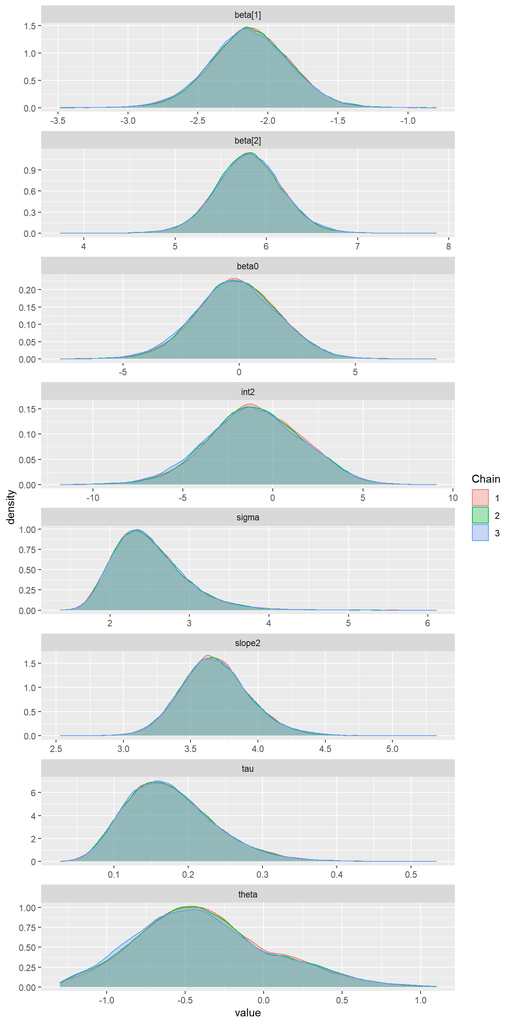

```r
# Uncomment to see some diagnostics - left here because high autocorrelation
# diagMCMC( codaObject=codaSamples , parName="beta0" )
# diagMCMC( codaObject=codaSamples , parName="beta[1]" )
# diagMCMC( codaObject=codaSamples , parName="int2" )
# diagMCMC( codaObject=codaSamples , parName="slope2" )

# Quick check
library(ggmcmc)
s = ggs(codaSamples)
ggs_density(s)
```

```r
# Output of model
su = summary(codaSamples)
su
```

```
##
## Iterations = 1001:34340
## Thinning interval = 1
## Number of chains = 3
## Sample size per chain = 33340
##
## 1. Empirical mean and standard deviation for each variable,
##    plus standard error of the mean:
##
##            Mean      SD  Naive SE Time-series SE
## beta[1] -2.1275 0.28545 0.0009026      0.0051046
## beta[2]  5.8105 0.36916 0.0011673      0.0048631
## beta0   -0.1102 1.78321 0.0056384      0.0327879
## int2    -0.9902 2.61401 0.0082654      0.0488244
## sigma    2.4918 0.45346 0.0014338      0.0022410
## slope2   3.6830 0.25907 0.0008192      0.0027959
## tau      0.1762 0.05994 0.0001895      0.0002845
## theta   -0.3758 0.42804 0.0013534      0.0070110
##
## 2. Quantiles for each variable:
##
##             2.5%     25%     50%     75%   97.5%
## beta[1] -2.69418 -2.3138 -2.1296 -1.9385 -1.5662
## beta[2]  5.08398  5.5708  5.8091  6.0482  6.5435
## beta0   -3.62584 -1.2819 -0.1271  1.0796  3.3796
## int2    -6.15925 -2.7389 -1.0278  0.7944  4.0525
## sigma    1.79178  2.1720  2.4285  2.7434  3.5537
## slope2   3.20602  3.5092  3.6708  3.8421  4.2341
## tau      0.07918  0.1329  0.1696  0.2120  0.3115
## theta   -1.12280 -0.6776 -0.4169 -0.1167  0.5568
```

### 9. b,iii) Plot Estimating Lines over Data

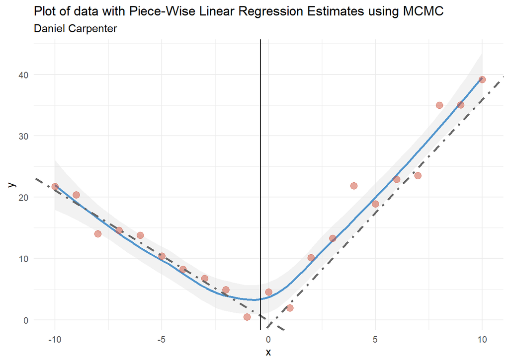

```r
# Create objects using summary stats
beta0  = su$statistics[,'Mean']['beta0']
beta1  = su$statistics[,'Mean']['beta[1]']
beta2  = su$statistics[,'Mean']['beta[2]']
int2   = su$statistics[,'Mean']['int2']
slope2 = su$statistics[,'Mean']['slope2']
theta  = su$statistics[,'Mean']['theta']

# Plot the two estimated linear pieces with the cuttoff point
basePlot +

  # Piece 1
  geom_abline(intercept = beta0, slope = beta1 ,
              linetype = 'dotdash', size = 1, color = 'grey40')  +


  # Piece 2
  geom_abline(intercept = int2,  slope = slope2,
              linetype = 'dotdash', size = 1, color = 'grey40') + # Piece 2
  geom_vline(xintercept = theta)                 + # Intersection
  labs(title = 'Plot of data with Piece-Wise Linear Regression Estimates using MCMC')
```

### Final Remarks on Enhancements to model

- Note the intercept of the second piece may or may not reflect the data (See graph)
- Note high autocorelation among the variables.
- Centering will not fix this issue, but I anticipate that a potential enhancement to the model would be to determine a fix for the intercept issue.

# Question 10 - Centering Data

Below shows the data

```r
# For x and y
x=50:80
set.seed(24)
y=10+2*x+rnorm(31,0,10)

# For xx and yy (notice centered around 0)
xx=-15:15
set.seed(24)
yy=10+2*xx+rnorm(31,0,10)
```

## 10. a) Plot data

```r
df2 = data.frame(x=x,
                y=y,

                xx=xx,
                yy=yy)
head(df2)
```

```
##    x        y  xx        yy
## 1 50 104.5412 -15 -25.45881
## 2 51 117.3659 -14 -12.63415
## 3 52 118.1962 -13 -11.80377
## 4 53 110.1637 -12 -19.83627
## 5 54 126.4746 -11  -3.52540
## 6 55 122.6602 -10  -7.33978
```

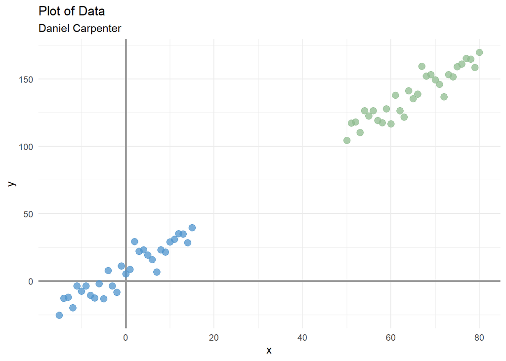

```r
require(ggplot2)
ggplot(df2) +

  # Emphasize the x and y axis
  geom_hline(aes(yintercept = 0), size = 1, color = 'grey60') +
  geom_vline(aes(xintercept = 0), size = 1, color = 'grey60') +

  # Two grouping
  geom_point(aes(x=x,  y=y ), color ='darkseagreen', alpha = 0.75, size = 3) +
  geom_point(aes(x=xx, y=yy), color ='steelblue3',    alpha = 0.75, size = 3) +

  theme_minimal() +
  labs(title = 'Plot of Data',
       subtitle = 'Daniel Carpenter')
```

## 10. b) 2 SLR Jags Models

### This is the base function for each SLR Model to run

```r
MyJagsSLR <- function(y, x ) {

  Ntotal = length(y)  # Compute the total number of x,y pairs.
  dataList = list(    # Put the information into a list.
    x = x,
    y = y ,
    Ntotal = Ntotal
  )

  modelStringSLR = "
  model{
      for( i in 1 : Ntotal ) {
          y[i] ~ dnorm(mu[i], tau)
          mu[i] <- beta0 + beta1 * x[i]
      }
      beta0 ~ dnorm(0.0, 1.0E-6)
      beta1 ~ dnorm(0.0, 1.0E-6)
      sigma ~ dunif(0, 1000)
      tau <- pow(sigma,  -2)
  }
  " # close quote for modelString
  writeLines( modelStringSLR , con="slrModel.txt" )

  # Initialize the chains based on MLE of data.
  initsList = list(beta0 = 0, beta1 = 0, sigma =10)

  # Run the chains:
  jagsModel = jags.model( file="slrModel.txt" , data=dataList , inits=initsList ,
                          n.chains=3 , n.adapt=500 )
  update( jagsModel , n.iter=500 )
  codaSamples = coda.samples( jagsModel , variable.names=c("beta0", "beta1", "sigma") ,
                              n.iter=33340 )

  return(list('codaSamples' = codaSamples,
              'summary'     = summary(codaSamples)
              )
        )
}
```

### 10. b, i) Jags Model 1

```r
# Call SLR Jags model (for x and y)
codaSamples1 <- MyJagsSLR(y=y, x=x)
# Retrieve the summary stats (for x and y)
codaSamples1$summary
```

```
##
## Iterations = 1001:34340
## Thinning interval = 1
## Number of chains = 3
## Sample size per chain = 33340
##
## 1. Empirical mean and standard deviation for each variable,
##    plus standard error of the mean:
##
##         Mean     SD  Naive SE Time-series SE
## beta0 15.793 9.7364 0.0307861       0.310388
## beta1  1.886 0.1484 0.0004692       0.004751
## sigma  7.454 1.0399 0.0032880       0.005753
##
## 2. Quantiles for each variable:
##
##         2.5%   25%    50%    75%  97.5%
## beta0 -3.442 9.306 15.880 22.276 34.790
## beta1  1.597 1.787  1.884  1.985  2.180
## sigma  5.756 6.718  7.342  8.060  9.806
```

### 10. b, ii) Jages Model 2

```r
# Call SLR Jags model (for xx and yy)
codaSamples2 <- MyJagsSLR(y=yy, x=xx)
# Retrieve the summary stats (for xx and yy)
codaSamples2$summary
```

```
##
## Iterations = 1001:34340
## Thinning interval = 1
## Number of chains = 3
## Sample size per chain = 33340
##
## 1. Empirical mean and standard deviation for each variable,
##    plus standard error of the mean:
##
##        Mean     SD Naive SE Time-series SE
## beta0 8.346 1.3542 0.004282       0.004259
## beta1 1.887 0.1518 0.000480       0.000482
## sigma 7.467 1.0496 0.003319       0.004961
##
## 2. Quantiles for each variable:
##
##        2.5%   25%   50%   75%  97.5%
## beta0 5.668 7.458 8.352 9.238 11.011
## beta1 1.588 1.786 1.887 1.987  2.186
## sigma 5.757 6.727 7.348 8.081  9.846
```

## 10. c) Posterior Density Plots

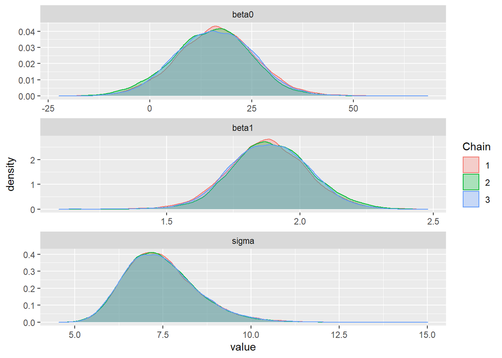

```r
library(ggmcmc)

# Density Plots
ggs_density(ggs(codaSamples1$codaSamples)) # (for x  and y )
```

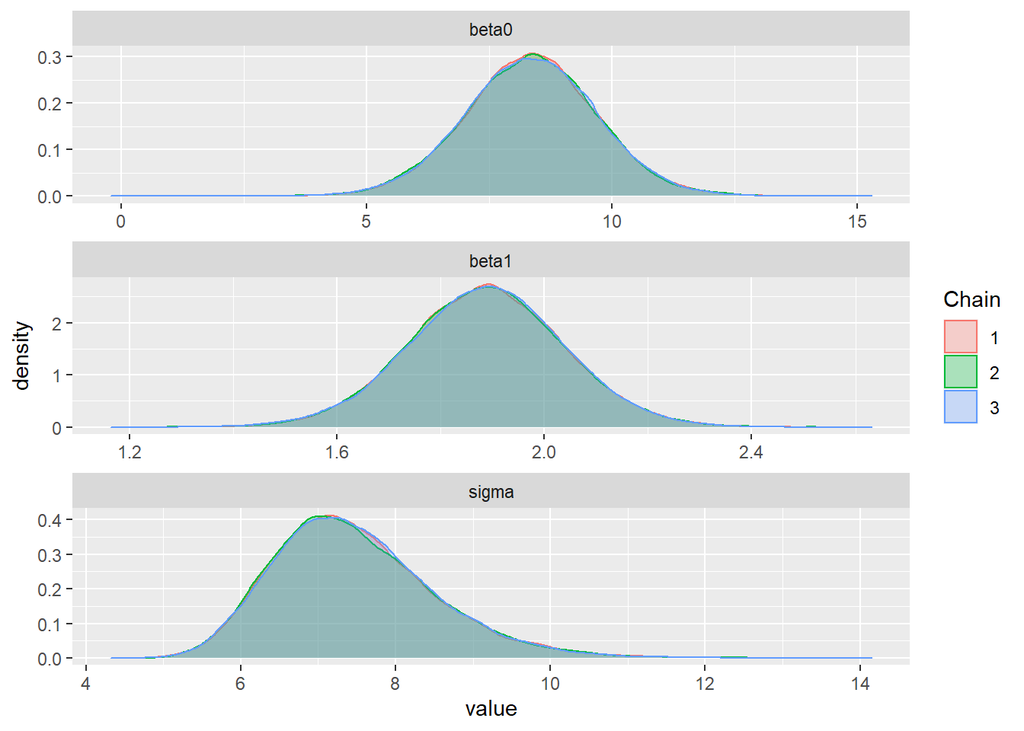

```r
ggs_density(ggs(codaSamples2$codaSamples)) # (for xx and yy)
```

## 10. d) Differing Intervals Interpretation

### Explain why the intervals for $\beta_0$ are so different.

- Since the `xx` and `yy` dataset are centered around 0, it allows for:
  - convergence among the chains
  - Low levels of cross-correlation
  - Extremely stable results
- It is obvious that the `x` and `y` model is not centered (visually and from the summary results.)
- To overcome this, we could just make a Jags script to center the data around 0

### Make reference to the density plots also.

- For the non-centered model:
  - You can see that there are “fatter” tails for the non-centered model. Not stationary.
  - Chains do not represent each other as well as the centered model

## 10. e) Classical estimates of the two models

### Use the function `lm()` and make classical 95% confidence interval estimates for the

```r
# Non-centered data
est.nonCenter <- lm(y  ~ x , data = df2)
summary(est.nonCenter)
```

```
##
## Call:
## lm(formula = y ~ x, data = df2)
##
## Residuals:
##     Min      1Q  Median      3Q     Max
## -14.656  -4.718   1.471   4.614  17.237
##
## Coefficients:
##             Estimate Std. Error t value Pr(>|t|)
## (Intercept)  15.7178     9.3954   1.673    0.105
## x             1.8867     0.1432  13.176 9.05e-14 ***
## ---
## Signif. codes:  0 '***' 0.001 '**' 0.01 '*' 0.05 '.' 0.1 ' ' 1
##
## Residual standard error: 7.131 on 29 degrees of freedom
## Multiple R-squared:  0.8569, Adjusted R-squared:  0.8519
## F-statistic: 173.6 on 1 and 29 DF,  p-value: 9.052e-14
```

```r
# Centered data
est.centered  <- lm(yy ~ xx, data = df2)
summary(est.centered)
```

```
##
## Call:
## lm(formula = yy ~ xx, data = df2)
##
## Residuals:
##     Min      1Q  Median      3Q     Max
## -14.656  -4.718   1.471   4.614  17.237
##
## Coefficients:
##             Estimate Std. Error t value Pr(>|t|)
## (Intercept)   8.3525     1.2808   6.521 3.85e-07 ***
## xx            1.8867     0.1432  13.176 9.05e-14 ***
## ---
## Signif. codes:  0 '***' 0.001 '**' 0.01 '*' 0.05 '.' 0.1 ' ' 1
##
## Residual standard error: 7.131 on 29 degrees of freedom
## Multiple R-squared:  0.8569, Adjusted R-squared:  0.8519
## F-statistic: 173.6 on 1 and 29 DF,  p-value: 9.052e-14
```

### Compare to bayesian estimates

- The models come up with same results, which is concerning!
- Proves the point that you could get bad results without centering your data